# Relatório GLM para dados binários

Clara Buck

2025-11-12

## 1 Introdução

Este relatório apresenta uma análise exploratória sobre a relação entre o **tamanho do peixe-leão (*Pterois spp.*)** e a **profundidade dos pontos de mergulho** no arquipélago de Fernando de Noronha.  
Os dados foram obtidos a partir de campanhas de monitoramento e registros de mergulhos entre 2020 e 2023. O objetivo principal é observar padrões iniciais de variação do comprimento total dos indivíduos em diferentes **estratos de profundidade** (rasos e fundos), considerando também variáveis associadas à **exposição e categoria de unidade de conservação**.

As análises apresentadas a seguir buscam identificar tendências visuais e possíveis relações que servirão de base para modelos posteriores de predição (GLM).

## 2 1. Carregamento e preparação dos dados

Nesta seção são instalados e carregados os pacotes necessários, e o banco de dados é importado para o ambiente de trabalho.  
Em seguida, são realizadas transformações de variáveis e criação de novas categorias, incluindo o **estrato de profundidade** (raso/fundo).

```r
if(!require(readxl)){install.packages('readxl'); library(readxl)}
if(!require(plyr)){install.packages('plyr'); library(plyr)}
if(!require(tidyverse)){install.packages('tidyverse'); library(tidyverse)}
if(!require(dplyr)){install.packages('dplyr'); library(dplyr)}

# Leitura do banco de dados

# df <- readr::read_csv("C:/Users/Dell/Documents/analises_lionfish/BD_lionfish_biometria.csv",
#                       na = c("na","NA"))

df <- readr::read_csv("/Users/mcruf/Library/CloudStorage/OneDrive-Personal/Arbeit/Lectures_and_Talks/UFRN/Lectures/ECL0072-GLM_GAM/Avaliacao/Grupo_11/BD_lionfish_biometria.csv",
                      na = c("na","NA"))


# Criação de estrato de profundidade
df$estrato <- ifelse(df$prof_m <= 30, "raso", "fundo")

# Conversão de variáveis categóricas
df$uc   <- as.factor(df$uc)
df$data <- as.factor(df$data)
df$site <- as.factor(df$site)
df$expo <- as.factor(df$expo)
df$estrato <- as.factor(df$estrato)
```

## 3 2. Criação de variáveis binárias

Aqui, as variáveis categóricas foram convertidas para formato binário (0 e 1), com o objetivo de facilitar futuras análises de modelos lineares generalizados (GLM).

```r
df$cat_uc <- ifelse(df$uc == "PARNAFN",1, 0) %>% as.factor()
df$cat_expo <- ifelse(df$expo == "dentro",1, 0) %>% as.factor()
df$cat_estrato <- ifelse(df$estrato == "raso",1, 0) %>% as.factor()

# Conferência
str(df)
```

```
## spc_tbl_ [299 × 12] (S3: spec_tbl_df/tbl_df/tbl/data.frame)
##  $ uc         : Factor w/ 2 levels "APAFN","PARNAFN": 1 1 2 1 1 1 2 2 2 2 ...
##  $ data       : Factor w/ 26 levels "abr/22","abr/23",..: 6 12 3 3 3 25 25 25 25 25 ...
##  $ site       : Factor w/ 52 levels "Alagados da Raquel",..: 35 35 17 35 34 35 34 16 16 18 ...
##  $ expo       : Factor w/ 2 levels "dentro","fora": 1 1 1 1 1 1 1 1 1 1 ...
##  $ peso_g     : num [1:299] 87 7 7 17 19 18 21 18 24 38 ...
##  $ ct_cm      : num [1:299] 20.3 8.1 8.87 11.86 12.22 ...
##  $ cp_cm      : num [1:299] 15.2 6.5 NA NA NA 8.7 9 9.1 10.1 10.2 ...
##  $ prof_m     : num [1:299] 27 27 14 27 23 27 23 32 32 9 ...
##  $ estrato    : Factor w/ 2 levels "fundo","raso": 2 2 2 2 2 2 2 1 1 2 ...
##  $ cat_uc     : Factor w/ 2 levels "0","1": 1 1 2 1 1 1 2 2 2 2 ...
##  $ cat_expo   : Factor w/ 2 levels "0","1": 2 2 2 2 2 2 2 2 2 2 ...
##  $ cat_estrato: Factor w/ 2 levels "0","1": 2 2 2 2 2 2 2 1 1 2 ...
##  - attr(*, "spec")=
##   .. cols(
##   ..   uc = col_character(),
##   ..   data = col_character(),
##   ..   site = col_character(),
##   ..   expo = col_character(),
##   ..   peso_g = col_double(),
##   ..   ct_cm = col_double(),
##   ..   cp_cm = col_double(),
##   ..   prof_m = col_double()
##   .. )
##  - attr(*, "problems")=<externalptr>
```

## 4 3. Relação entre comprimento total e estrato de profundidade

Nesta análise exploratória é avaliada a variação do comprimento total (cm) dos indivíduos em função do estrato de profundidade. São apresentados dois tipos de visualização:

- Nuvem de pontos – mostrando a dispersão dos dados.
- Boxplot – evidenciando a mediana e a variação dos comprimentos em cada estrato.

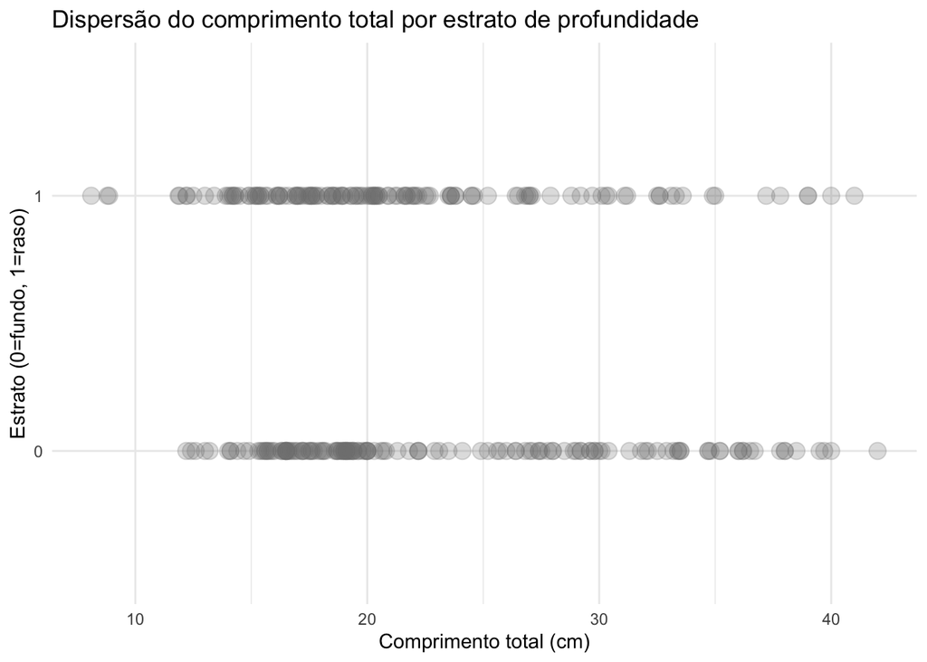

```r
df %>%
filter(!is.na(ct_cm) & !is.na(cat_estrato)) %>%
ggplot(aes(x = ct_cm, y = cat_estrato)) +
geom_point(size = 4, col = 'gray50', alpha = 0.25) +
theme_minimal() +
labs(x = "Comprimento total (cm)", y = "Estrato (0=fundo, 1=raso)",
title = "Dispersão do comprimento total por estrato de profundidade")
```

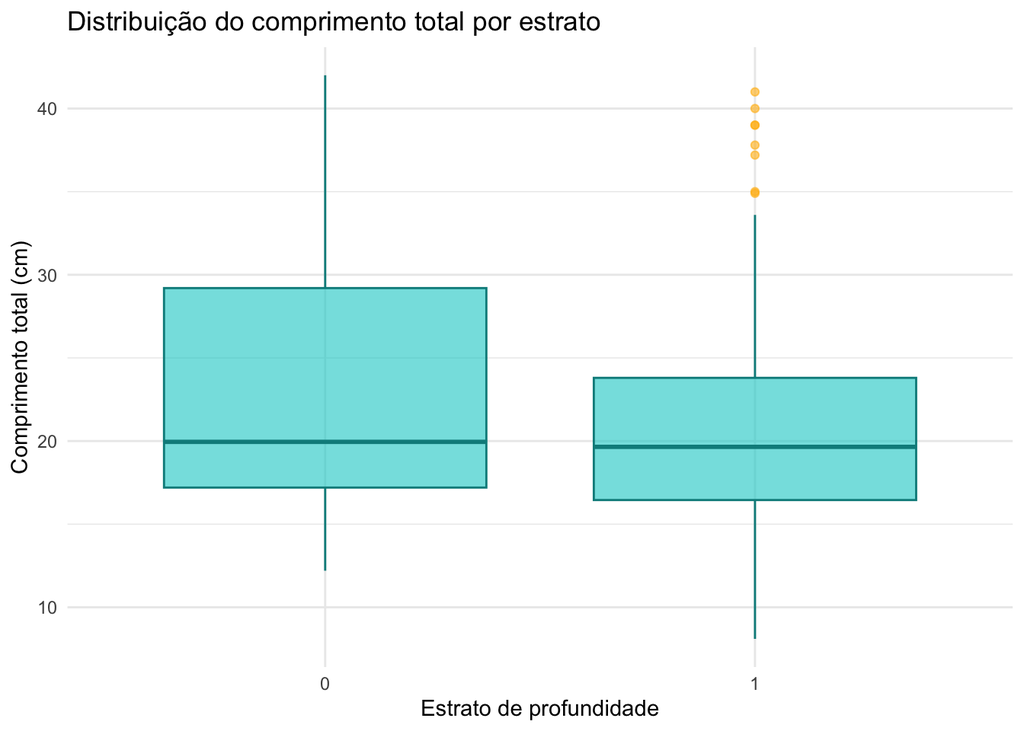

```r
df %>%
filter(!is.na(ct_cm) & !is.na(cat_estrato)) %>%
ggplot(aes(x = cat_estrato, y = ct_cm)) +
geom_boxplot(fill = "cyan3", color = "cyan4", alpha = 0.6, outlier.color = "darkgoldenrod1") +
theme_minimal() +
labs(x = "Estrato de profundidade", y = "Comprimento total (cm)",
title = "Distribuição do comprimento total por estrato")
```

Podemos perceber pelo boxplot uma maior concentração de indivíduos maiores em estratos mais profundos do arquipélago, enquanto indivíduos menores se concentram em áreas mais rasas.